# Modelagem

Modelos de Regressao em Painel e Analise DEA (SIOPE vs. SICONFI)

Rafael Abreu

## 1. Configuração do Ambiente

### 1.1. Instalação de Pacotes (Apenas se necessário)

Este bloco não é executado (`eval=FALSE`). Se você ainda não tem os pacotes, copie e cole estas linhas no seu **Console** do RStudio para instalá-los.

```r
# Lista de pacotes para a análise
pacotes_necessarios <- c(
  "readxl",               # para ler arquivos excel
  "dplyr",                # para manipulação de dados
  "plm",                  # para análise de dados em painel
  "lmtest",               # testes para modelos de regressão
  "zoo",                  # para séries temporais e janelas móveis
  "PerformanceAnalytics", # análise exploratória
  "tseries",              # para séries temporais: análise de tendência, etc.
  "tidyverse",            # para manipulação de dados
  "gtsummary",            # para melhor visualização de tabelas
  "ggrepel",              # para gráficos
  "deaR",                 # para Análise de Envoltória de Dados
  "broom",                # para melhor visualização de análises estatísticas
  "broom.helpers",
  "litedown",
  "patchwork",
  "glue",
  "kebleExtra",
  "ggraph",
  "tidygraph"
  "knitr"
  "ggplot2"
)

install.packages(pacotes_necessarios)
```

### 1.2. Carregamento dos Pacotes

Aqui carregamos todas as bibliotecas que serão usadas no relatório.

```r
library(readxl)
library(dplyr)
library(plm)
library(lmtest)
library(zoo)
library(tidyverse)
library(gtsummary)
library(deaR)
library(ggrepel)
library(broom)
library(broom.helpers)
library(litedown)
library(patchwork)
library(glue)
library(kableExtra)
library(ggraph)
library(tidygraph)
library(knitr)
library(ggplot2)
```

## 2. Carga e Preparação dos Dados

Primeiro, lemos as duas abas da planilha “dados_mucuri.xlsx” e as unimos usando as chaves `ano`, `id_ente` e `nom_munic`.

```r
dados_qualidade <- read_excel("dados_mucuri.xlsx", sheet = "qualidade")
dados_gastos <- read_excel("dados_mucuri.xlsx", sheet = "gasto")

dados_completos <- left_join(dados_gastos, dados_qualidade, by = c("ano", "id_ente", "nom_munic"))

# Usamos glimpse() para uma visualização rápida da estrutura dos dados
glimpse(dados_completos)
```

```
## Rows: 117
## Columns: 9
## $ ano                 <dbl> 2015, 2015, 2015, 2015, 2015, 2015, 2015, 2015, 20…
## $ id_ente             <dbl> 3100906, 3104700, 3113701, 3126802, 3127057, 31323…
## $ nom_munic           <chr> "Águas Formosas", "Ataléia", "Carlos Chagas", "Fre…
## $ gasto_aluno_SIOPE   <dbl> 4499.187, 3135.075, 2443.781, 2370.562, 3641.837, …
## $ gasto_aluno_SICONFI <dbl> 4535.783, 3924.822, 2291.972, 2482.505, 2636.991, …
## $ populacao           <dbl> 365712, 269572, 401800, 84434, 61945, 199824, 4033…
## $ tamanho             <chr> "Grande", "Grande", "Grande", "Grande", "Grande", …
## $ lp_adequado         <dbl> NA, NA, NA, NA, NA, NA, NA, NA, NA, NA, NA, NA, NA…
## $ mt_adequado         <dbl> NA, NA, NA, NA, NA, NA, NA, NA, NA, NA, NA, NA, NA…
```

## 3. Criação do Índice Sintético de Qualidade (PCA)

Para criar uma variável dependente única, aplicamos a Análise de Componentes Principais (PCA) sobre os indicadores de proficiência adequada em Português (`lp_adequado`) e Matemática (`mt_adequado`).

```r
# Seleciona e padroniza as colunas para o PCA
matriz_pca <- dados_qualidade %>%
  dplyr::select(lp_adequado, mt_adequado) %>%
  scale()

# Executa o PCA
pca_resultado <- prcomp(matriz_pca)

# Verifica a variância explicada pelo primeiro componente
print(summary(pca_resultado))
```

```
## Importance of components:
##                           PC1    PC2
## Standard deviation     1.3053 0.5442
## Proportion of Variance 0.8519 0.1481
## Cumulative Proportion  0.8519 1.0000
```

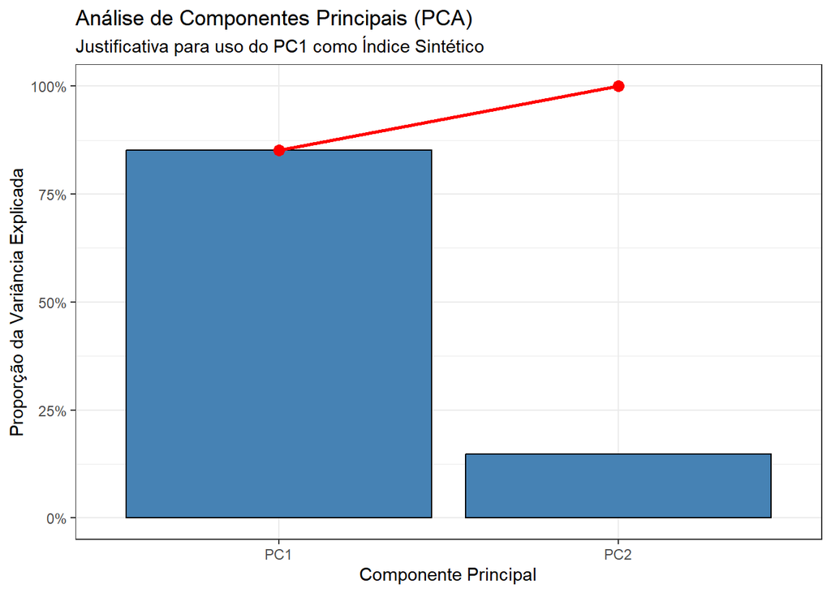

```r
# Extrai o primeiro componente principal (PC1) como nosso índice
dados_qualidade$indice_qualidade <- pca_resultado$x[, 1]

# ----- GRÁFICO 1: PCA -----
# Este gráfico mostra a importância de cada componente.

# Extrai a importância
pca_importancia <- as.data.frame(t(summary(pca_resultado)$importance))
pca_importancia$componente <- rownames(pca_importancia)

ggplot(pca_importancia, aes(x = componente, y = `Proportion of Variance`)) +
  geom_col(fill = "steelblue", color = "black") +
  geom_line(aes(y = `Cumulative Proportion`, group = 1), color = "red", linewidth = 1) +
  geom_point(aes(y = `Cumulative Proportion`), color = "red", size = 3) +
  scale_y_continuous(labels = scales::percent) +
  labs(
    title = "Análise de Componentes Principais (PCA)",
    subtitle = "Justificativa para uso do PC1 como Índice Sintético",
    x = "Componente Principal",
    y = "Proporção da Variância Explicada"
  ) +
  theme_bw()
```

Após criar o índice, nós o adicionamos à base completa e removemos as colunas originais (`lp_adequado`, `mt_adequado`) e objetos desnecessários.

```r
# Adiciona índice sintético ao painel com todos os dados
dados_completos <- dados_completos %>%
  left_join(dados_qualidade %>% dplyr::select(ano, id_ente, indice_qualidade), by = c("ano", "id_ente"))

# Limpa variáveis
rm(matriz_pca)
dados_completos$lp_adequado <- NULL
dados_completos$mt_adequado <- NULL
```

## 4. Engenharia de Variáveis (Construção do Painel)

```r
painel <- dados_completos %>%
  dplyr::arrange(id_ente, ano) %>%
  dplyr::group_by(id_ente) %>%
  dplyr::mutate(
    # Padroniza o índice de qualidade
    #indice_qualidade_std = as.vector(scale(indice_qualidade)),
    indice_qualidade_std = as.vector(indice_qualidade),

    # Aplica o logaritmo no investimento
    log_gasto_siope = log(gasto_aluno_SIOPE),
    log_gasto_siconfi = log(gasto_aluno_SICONFI),

    #--- Variáveis para a Abordagem 1 (Defasagens Distribuídas) ---
    # Primeira diferença do investimento
    d_log_gasto_siope = log_gasto_siope - dplyr::lag(log_gasto_siope),
    d_log_gasto_siconfi = log_gasto_siconfi - dplyr::lag(log_gasto_siconfi),

    #--- Variáveis para a Abordagem 2 (Gasto Acumulado) ---
    # Média móvel de 3 anos do investimento EM NÍVEL
    media_movel_3a_siope = zoo::rollmean(log_gasto_siope, k = 3, fill = NA, align = "right"),
    media_movel_3a_siconfi = zoo::rollmean(log_gasto_siconfi, k = 3, fill = NA, align = "right")
  ) %>%
  dplyr::ungroup()
```

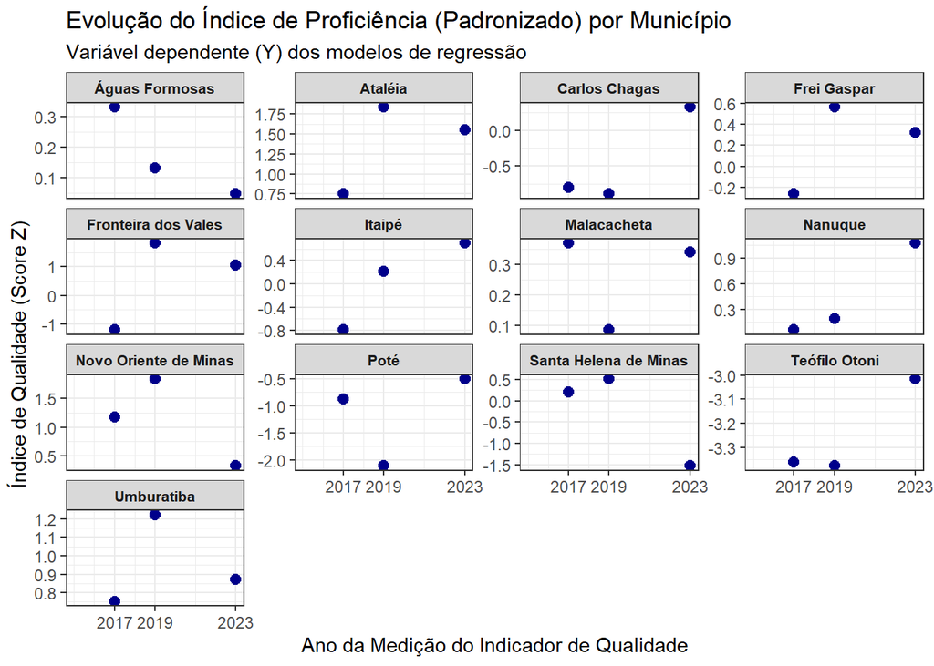

```r
# ----- GRÁFICO 2: EVOLUÇÃO DO ÍNDICE DE PROFICIÊNCIA (Variável Dependente) -----
ggplot(painel, aes(x = ano, y = indice_qualidade_std)) +
  geom_line(color = "darkblue", linewidth = 1, linetype = "dotted") +
  geom_point(color = "darkblue", size = 2.5) +
  facet_wrap(~ nom_munic, scales = "free_y", ncol = 4) +

  # --- AJUSTE SOLICITADO ---
  # Força o eixo X a mostrar apenas os anos de medição
  scale_x_continuous(breaks = c(2017, 2019, 2023)) +

  labs(
    title = "Evolução do Índice de Proficiência (Padronizado) por Município",
    subtitle = "Variável dependente (Y) dos modelos de regressão",
    x = "Ano da Medição do Indicador de Qualidade", # Rótulo mais preciso
    y = "Índice de Qualidade (Score Z)"
  ) +
  theme_bw() +
  theme(strip.text = element_text(size = 8, face = "bold"))
```

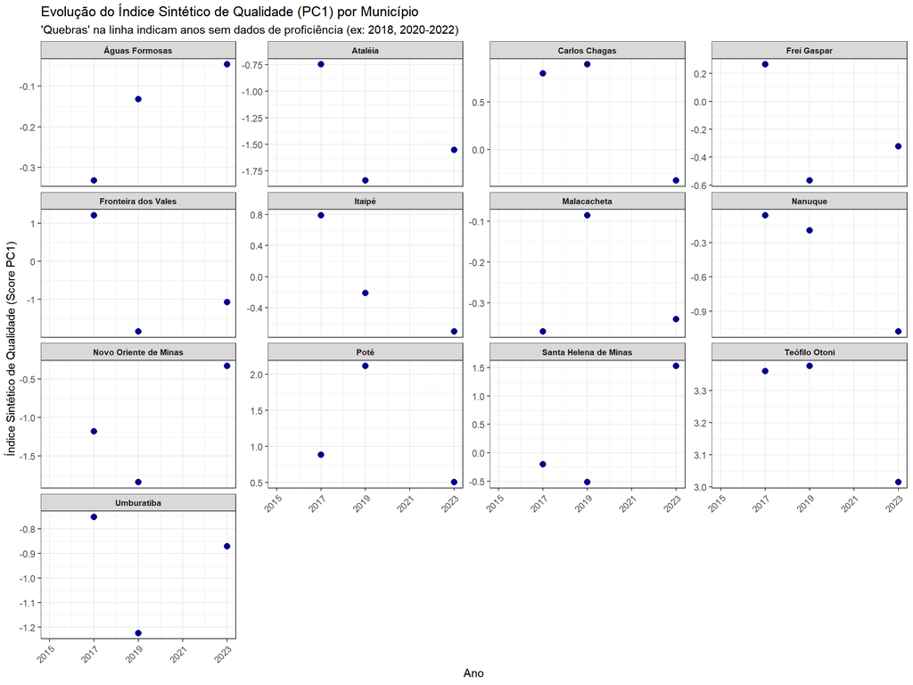

```r
# ----- GRÁFICO 3: Evolução do Índice Sintético de Qualidade por Município -----
# Este gráfico plota o 'indice_qualidade' (PC1).

ggplot(dados_completos, aes(x = ano, y = -indice_qualidade)) +
  # Usamos geom_line() para conectar os pontos e geom_point() para marcá-los
  # A linha irá "quebrar" automaticamente onde há dados faltantes (NA)
  geom_line(color = "darkblue", linewidth = 1, na.rm = TRUE) +
  geom_point(color = "darkblue", size = 2.5, na.rm = TRUE) +

  # O pedido central: um painel por município
  facet_wrap(~ nom_munic, scales = "free_y", ncol = 4) +

  # Ajusta o eixo X para mostrar todos os anos,
  # deixando claros os "gaps" de dados
  scale_x_continuous(breaks = seq(min(dados_completos$ano), max(dados_completos$ano), by = 2)) +

  labs(
    title = "Evolução do Índice Sintético de Qualidade (PC1) por Município",
    subtitle = "'Quebras' na linha indicam anos sem dados de proficiência (ex: 2018, 2020-2022)",
    x = "Ano",
    y = "Índice Sintético de Qualidade (Score PC1)"
  ) +
  theme_bw() +
  theme(
    strip.text = element_text(size = 8, face = "bold"),
    axis.text.x = element_text(angle = 45, hjust = 1)
  )
```